# 06_make_phenofiles

Heather E. Wheeler

2015-12-31 09:18:08

### Load packages, functions, paths

```r
library(dplyr)
library(tidyr)
library(ggplot2)
library(sas7bdat) ##read SAS files
library(foreign) ##read SPSS files, doesn't work with Fossa file, ask Ryan to convert to txt
library(psych)
library(MASS)
"%&%" = function(a,b) paste(a,b,sep="")
elementMean <- function(my.list) {
  arr <- array(unlist(my.list),c(dim(my.list[[1]])[1],dim(my.list[[1]])[2],length(my.list)))
  rowMeans( arr , na.rm=TRUE, dims = 2 )
}
source("/Volumes/dolan-lab/hwheeler/ThePlatinumStudy/CIPN_modeling/ztransform.R")
source("/Volumes/dolan-lab/hwheeler/ThePlatinumStudy/CIPN_modeling/rntransform.R")
my.dir = "/Volumes/dolan-lab/hwheeler/ThePlatinumStudy/GWAS/"
pca.dir = "/Volumes/dolan-lab/hwheeler/ThePlatinumStudy/GWAS/PCA/"
pheno.dir = "/Volumes/dolan-lab/hwheeler/ThePlatinumStudy/GWAS/Datasets_from_Ryan_Cook_20151123/"
ptcov.dir <- my.dir %&% "genotypes/"
```

### pull height phenotype for GCTA

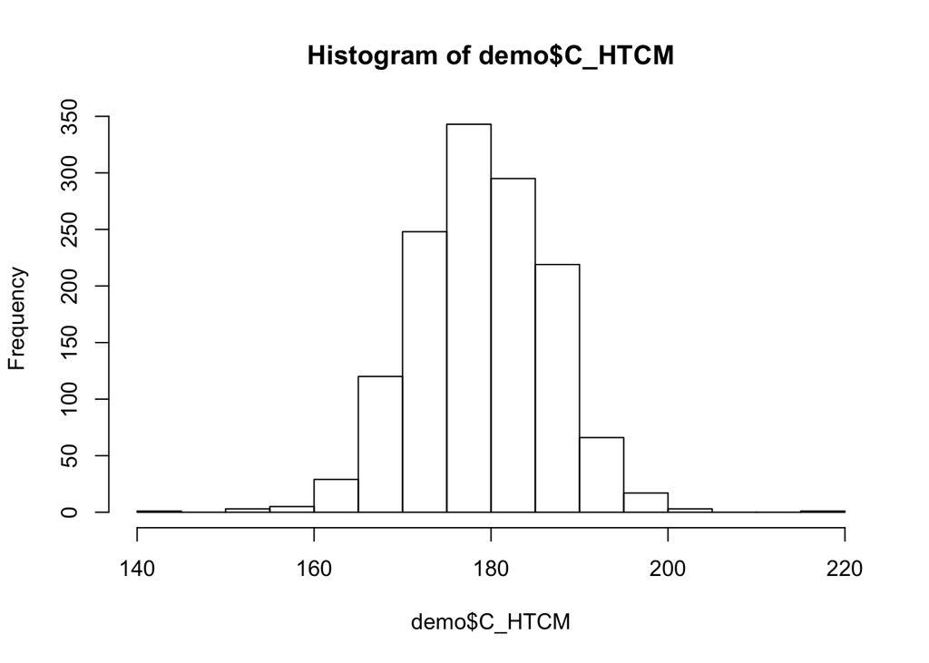

```r
norway <- read.csv(my.dir %&% "Norway_20150122/460platina110113 Helle.csv") %>% mutate(patno=as.character(Lopenr),C_HTCM=høyde2cm) %>% dplyr::select(patno,C_HTCM)
demo <- read.sas7bdat("/Volumes/dolan-lab/hwheeler/ThePlatinumStudy/GWAS/Datasets_from_Ryan_Cook_20151106/demographics.sas7bdat") %>% mutate(patno=as.character(patno)) %>% dplyr::select(patno,C_HTCM) #more ht phenotypes in this dataset
hist(demo$C_HTCM)
```

```r
fam <- read.table(my.dir %&% "genotypes/gctaQC/N88_Recluster_TOP_20150911_FinalReport.postQC.fam")
colnames(fam) <- c("FID","IID","father","mother","sex","pheno")
patnoinfo <- read.table(my.dir %&% "genotypes/FID_IID_patno.txt",header=TRUE)
genosamples <- inner_join(fam,patnoinfo,by="FID")
demoComb <- rbind(demo,norway)
demoComb <- demoComb[!duplicated(demoComb$patno), ]
height <- left_join(genosamples,demoComb,by="patno")
heightpheno <- dplyr::select(height,FID,IID.x,C_HTCM)
dim(heightpheno)
```

```
## [1] 938   3
```

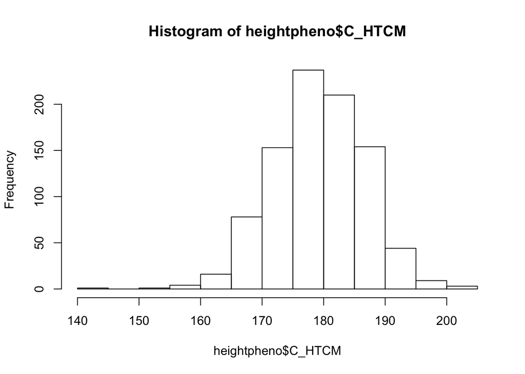

```r
hist(heightpheno$C_HTCM)
```

```r
write.table(heightpheno,my.dir %&% "GCTA/height_cm.phen",quote=FALSE,row.names = FALSE, col.names = FALSE)
##make shuffled phenofile
set.seed(101)
shuffleht <- base::sample(heightpheno$C_HTCM)
shufpheno <- dplyr::select(heightpheno,FID,IID.x) %>% mutate(shuffleht=shuffleht)
write.table(shufpheno,my.dir %&% "GCTA/shuffled_height_cm.phen",quote=FALSE,row.names = FALSE, col.names = FALSE)
```

### GCTA results

- See 07_gcta.sh for code

#### Height phenotype

```
Source  Variance    SE
V(G)    33.573465   13.114136
V(e)    19.141336   12.920689
Vp  52.714800   2.476070
V(G)/Vp 0.636889    0.245407
logL    -2258.906
logL0   -2270.947
LRT 24.081
df  1
Pval    4.618e-07
n   910
```

#### Shuffled height phenotype

```
Source  Variance    SE
V(G)    14.091383   16.237441
V(e)    39.849214   16.287943
Vp  53.940596   2.530541
V(G)/Vp 0.261239    0.300564
logL    -2270.443
logL0   -2270.947
LRT 1.008
df  1
Pval    0.1576
n   910
```

### Samples in QC’d genotypes that have exome data

- N88_Recluster_TOP_20150911_FinalReport.postPCA.euro.fam

```r
exomelist <- read.table("../RIKEN_genotyping/DSR_exomes_PATNO_kitNumber.txt",header=TRUE)
colnames(exomelist)<-c("IID","kitNumber") #submitted exome list
completedexomes <- read.table("../RIKEN_genotyping/DSR_completed_dolan_pgrn_co_1_lookup_table.txt",header=TRUE,sep="\t") %>% mutate(kitNumber=UDF.Investigator.Sample.Name) %>% dplyr::select(Sample.Name,kitNumber)
exomes <- inner_join(exomelist,completedexomes,by="kitNumber") %>% mutate(exome="Yes",IID=as.character(IID))
dim(exomes)
```

```
## [1] 194   4
```

```r
fam <- read.table(my.dir %&% "genotypes/N88_Recluster_TOP_20150911_FinalReport.postPCA.euro.fam")
colnames(fam) <- c("FID","IID","father","mother","sex","pheno")
gtinfo <- left_join(fam,exomes,by="IID") %>% mutate(exome=ifelse(is.na(exome),"No","Yes")) %>% dplyr::select(FID,IID,kitNumber,Sample.Name,exome)
write.table(gtinfo,my.dir %&% "PtStudy_passed_genoQC_exome_info.txt",quote=F,row.names = F)
##how many have exomes?
table(gtinfo$exome)
```

```
##
##  No Yes
## 768 185
```

### How many Norway genotyped samples have SCIN?

```r
demo <- read.sas7bdat("/Volumes/dolan-lab/hwheeler/ThePlatinumStudy/GWAS/Datasets_from_Ryan_Cook_20151106/demographics.sas7bdat") %>% mutate(patno=as.character(patno))
fam <- read.table(my.dir %&% "genotypes/N88_Recluster_TOP_20150911_FinalReport.fam")
colnames(fam) <- c("FID","IID","father","mother","sex","pheno")
patnoinfo <- read.table(my.dir %&% "genotypes/FID_IID_patno.txt",header=TRUE) %>% mutate(patno=as.character(patno))
genosamples <- inner_join(fam,patnoinfo,by="FID")
norgenosamples <- dplyr::filter(genosamples,grepl('T',IID.x))
##number Norway samples genotyped
dim(norgenosamples)[1]
```

```
## [1] 244
```

```r
norgenoscin <- inner_join(norgenosamples,demo,by="patno")
##number Norway samples genotyped with SCIN
dim(norgenoscin)[1]
```

```
## [1] 87
```

```r
##number Norway samples need SCIN for
dim(norgenosamples)[1]-dim(norgenoscin)[1]
```

```
## [1] 157
```

```r
morescin <-read.spss('/Users/heather/GitHub/ThePlatinumStudy/Ototoxicity_modeling/Norway_audiometry_20150221//Travis_DNA_audiogram CHEM_195 21.02.15.sav',to.data.frame=T) %>% mutate(patno=as.character(lopenr))
norgenoscin2 <- inner_join(norgenosamples,morescin,by="patno")
dim(norgenoscin2)
```

```
## [1] 87 28
```

```r
##make list for Eileen J. of what we have and need
norgenoinfo <- left_join(norgenosamples,demo,by="patno") %>% mutate(lopenr=patno,IID=IID.x) %>% dplyr::select(lopenr,FID,IID,C_Q27ARSP)
aud <- read.sas7bdat("/Volumes/dolan-lab/hwheeler/ThePlatinumStudy/GWAS/Datasets_from_Ryan_Cook_20151106/audiometry.sas7bdat") %>% mutate(lopenr=as.character(patno)) %>% filter(patno<30000,C_Audtest==1,C_EARLR==1)
norgenoinfo <- left_join(norgenoinfo,aud,by="lopenr")
a<- norgenoinfo %>% mutate(SCIN=ifelse(is.na(C_Q27ARSP),"No","Yes"), Audiometry=ifelse(is.na(C_EARLR),"No","Yes")) %>% dplyr::select(lopenr,FID,IID,SCIN,Audiometry)
write.table(a,file=my.dir %&% "Genotyped_Norway_samples_phenotype_info_2015-11-16.csv",sep=",",quote=F,row.names=F)
```

### Pull 4-12kHz audiometry geom mean phenotype

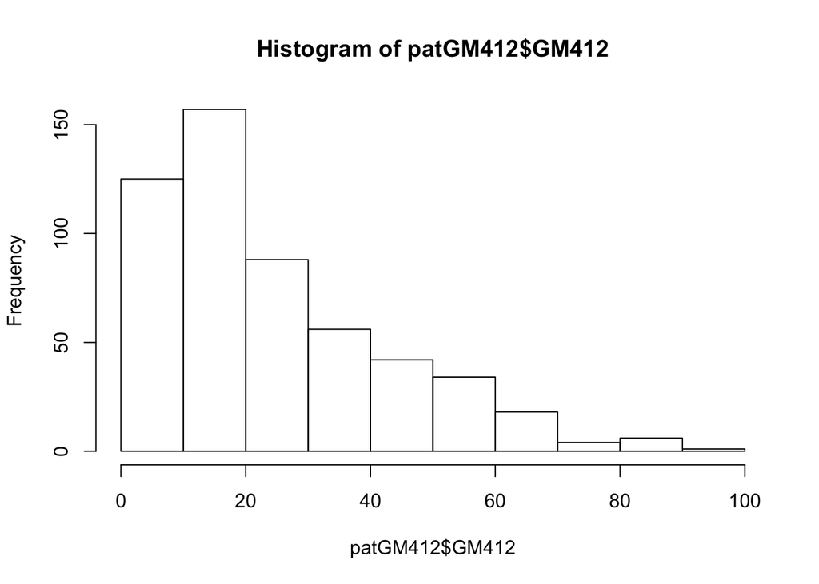

```r
fam <- read.table(my.dir %&% "genotypes/N88.forImputation.fam")
colnames(fam) <- c("FID","patno","father","mother","sex","pheno")
fam <- fam %>% mutate(IID=as.character(patno))
aud <- read.sas7bdat(pheno.dir %&% "audiometry.sas7bdat")
ageataudio <- read.sas7bdat(pheno.dir %&% "ageataudio.sas7bdat") %>% mutate(IID=as.character(patno))
finaldosing <- read.sas7bdat(pheno.dir %&% "finaldosing.sas7bdat") %>% mutate(IID=as.character(patno)) %>% dplyr::select(IID,CumlCispdose,CumlBLEOdose)
##divide by ear
airl<-filter(aud,C_AUDTEST==1,C_EARLR==1)
airr<-filter(aud,C_AUDTEST==1,C_EARLR==2)
###Pull db levels for 4-12 kHz
left <- airl %>% dplyr::select(C_CND4000, C_CND6000, C_CND8000, C_CND10000, C_CND12000)
right <- airr %>% dplyr::select(C_CND4000, C_CND6000, C_CND8000, C_CND10000, C_CND12000)
mean412 <- elementMean(list(left,right))
mean412<-replace(mean412,mean412<=1,1) ###set any db values <1 equal to 1, so can take the log
GM412 <- exp(rowMeans(log(mean412),na.rm=TRUE)) ##calc even if missing values
patGM412<- airl %>% dplyr::select(patno) %>% mutate(GM412=GM412,IID=as.character(patno))
patGM412 <- left_join(fam,patGM412,by="IID")
patageaudio <- left_join(fam,ageataudio,by="IID") %>% dplyr::select(FID,IID,ageaudio)
patcov <- left_join(patageaudio,finaldosing,by="IID")
hist(patGM412$GM412)
```

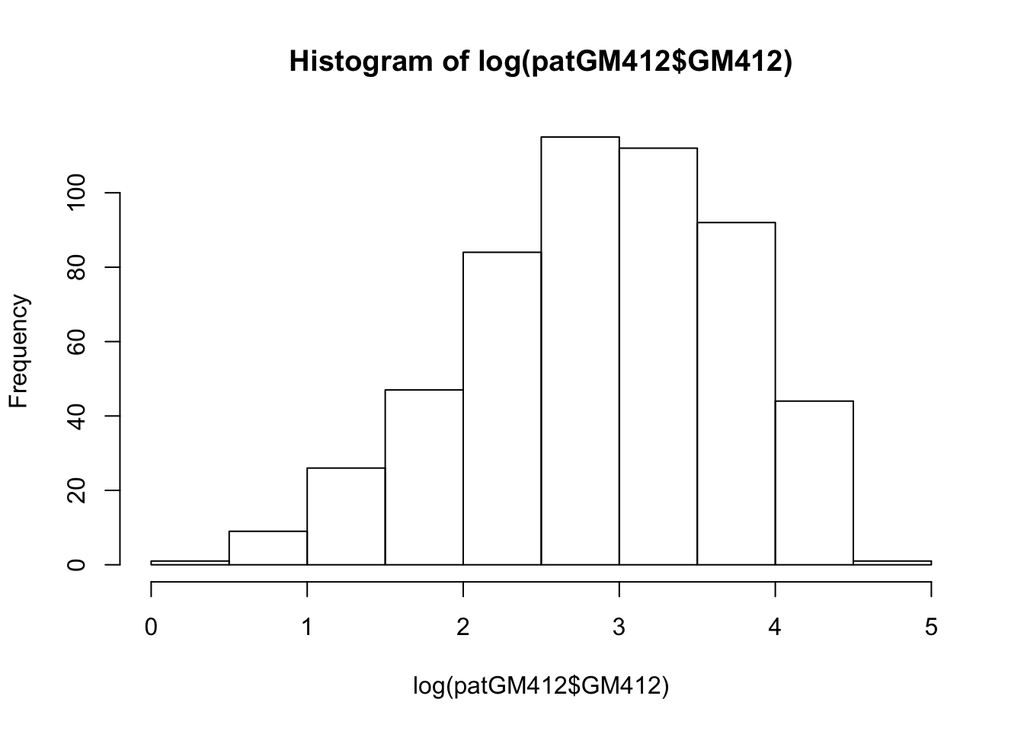

```r
hist(log(patGM412$GM412))
```

```r
shapiro.test(log(patGM412$GM412)) #rank-normalize?
```

```
##
##  Shapiro-Wilk normality test
##
## data:  log(patGM412$GM412)
## W = 0.98279, p-value = 6.422e-06
```

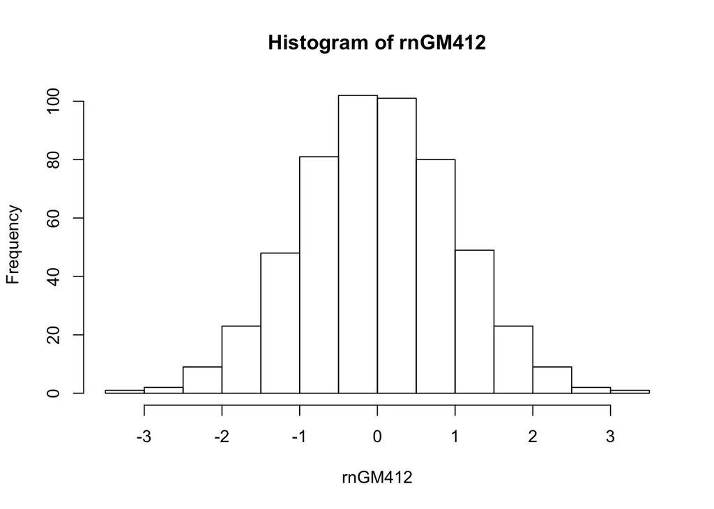

```r
rnGM412 <- rntransform(patGM412$GM412)
hist(rnGM412)
```

```r
patGM412 <- patGM412 %>% dplyr::select(FID,IID,GM412) %>% mutate(logGM412=log(GM412),rnGM412=rnGM412)

europcs <- read.table(my.dir %&% "genotypes/N88_euro_LDpruned_2015-11-18.evec",skip=1)
eupcdf <- europcs %>% rename(PC1=V2,PC2=V3,PC3=V4,PC4=V5,PC5=V6,PC6=V7,PC7=V8,PC8=V9,PC9=V10,PC10=V11)
patcov <- cbind(patcov,eupcdf[,2:11])

write.table(patGM412,file=my.dir %&% "genotypes/PtStudy.GM412.phenofile",quote=F,row.names = F,col.names = T)
write.table(patcov,file=my.dir %&% "genotypes/PtStudy.covfile",quote=F,row.names = F,col.names = T)

summary(lm(patGM412$rnGM412~patageaudio$ageaudio))$coef
```

```
##                         Estimate  Std. Error   t value     Pr(>|t|)
## (Intercept)          -2.37480025 0.145319131 -16.34197 6.752332e-49
## patageaudio$ageaudio  0.05948839 0.003532816  16.83880 2.927262e-51
```

```r
summary(lm(patGM412$rnGM412~patageaudio$ageaudio))$r.squared
```

```
## [1] 0.3489593
```

```r
#number nonmissing rnGM412 phenotypes (TRUE):
table(is.na(patGM412$rnGM412)==FALSE)
```

```
##
## FALSE  TRUE
##   422   531
```

```r
#number nonmissing ageaudio (TRUE):
table(is.na(patcov$ageaudio)==FALSE)
```

```
##
## FALSE  TRUE
##   422   531
```

```r
#number nonmissing CumlCispdose (TRUE):
table(is.na(patcov$CumlCispdose)==FALSE)
```

```
##
## FALSE  TRUE
##   261   692
```

```r
#pull Pt Study only
poppatGM412 <- patGM412 %>% mutate(pop=ifelse(grepl("TC",IID),"Norway","PtStudy"))
table(poppatGM412$pop)
```

```
##
##  Norway PtStudy
##     240     713
```

```r
PtpatGM412 <- poppatGM412 %>% dplyr::filter(pop=="PtStudy")
#number nonmissing rnGM412 phenotypes (TRUE):
table(is.na(PtpatGM412$rnGM412)==FALSE)
```

```
##
## FALSE  TRUE
##   182   531
```

```r
table(is.na(PtpatGM412$rnGM412)==FALSE)/sum(table(is.na(PtpatGM412$rnGM412)==FALSE))
```

```
##
##     FALSE      TRUE
## 0.2552595 0.7447405
```

### Divide sample into quartiles based on Engdahl

```r
###Pull db levels for 4-8 kHz
left <- airl %>% dplyr::select(C_CND4000, C_CND6000, C_CND8000)
right <- airr %>% dplyr::select(C_CND4000, C_CND6000, C_CND8000)
mean468 <- elementMean(list(left,right))
mean468<-replace(mean468,mean468<=1,1) ###set any db values <1 equal to 1, so can take the log
AUC468 <- exp(rowMeans(log(mean468)))
patData <- airl %>% dplyr::select(patno) %>% mutate(AUC_4_8kHz=AUC468)
a <- left_join(patData,ageataudio,by="patno")
patData <- a %>% dplyr::select(patno, ageaudio, AUC_4_8kHz)
###Define age groups per sample
group <- floor(patData$ageaudio) ##what I did previously, more pleasant graphic
for(i in 1:length(group)){
  if(is.na(group[i])){
    group[i] <- NA
  }
  else if(group[i] <= 29){
    group[i] <- 29
  }else if(group[i] > 29 && group[i] <= 39){
    group[i] <- 39
  }else if(group[i] > 39 && group[i] <= 49){
    group[i] <- 49
  }else if(group[i] > 49 && group[i] <= 59){
    group[i] <- 59
  }else if (group[i] > 59 && group[i] <= 69){
    group[i] <- 69
  }
}
patData <- patData %>% mutate(GROUP=group)
##4-8kHz normal AUCs calculated in Engdahl_def_quartiles.xlsx
engData <- read.table('~/GitHub/ThePlatinumStudy/Ototoxicity_modeling/Engdahl_quartile_AUCs_4-8kHz.txt',header=TRUE)
aucData <- left_join(patData,engData,by="GROUP")
aucData <- aucData[complete.cases(aucData),]

###calculate which quartile
quartile=aucData$AUC_4_8kHz
for(i in 1:dim(aucData)[1]){
  if(aucData$AUC_4_8kHz[i] < aucData$Q1[i]){
    quartile[i] <- 1
  }
  else if(aucData$AUC_4_8kHz[i] < aucData$Q2[i]){
    quartile[i] <- 2
  }
  else if(aucData$AUC_4_8kHz[i] < aucData$Q3[i]){
    quartile[i] <- 3
  }else{
    quartile[i] <- 4
  }
}

aucData <- mutate(aucData,QUARTILE=quartile,IID=as.character(patno))
phenCombo <- left_join(patGM412,aucData,by="IID")

table(aucData$QUARTILE)
```

```
##
##   1   2   3   4
## 130 211 158 121
```

```r
sum(table(aucData$QUARTILE))
```

```
## [1] 620
```

```r
table(aucData$QUARTILE)/sum(table(aucData$QUARTILE))
```

```
##
##         1         2         3         4
## 0.2096774 0.3403226 0.2548387 0.1951613
```

### Pull EORTC CIPN20: 8 sensory items (no hearing item)

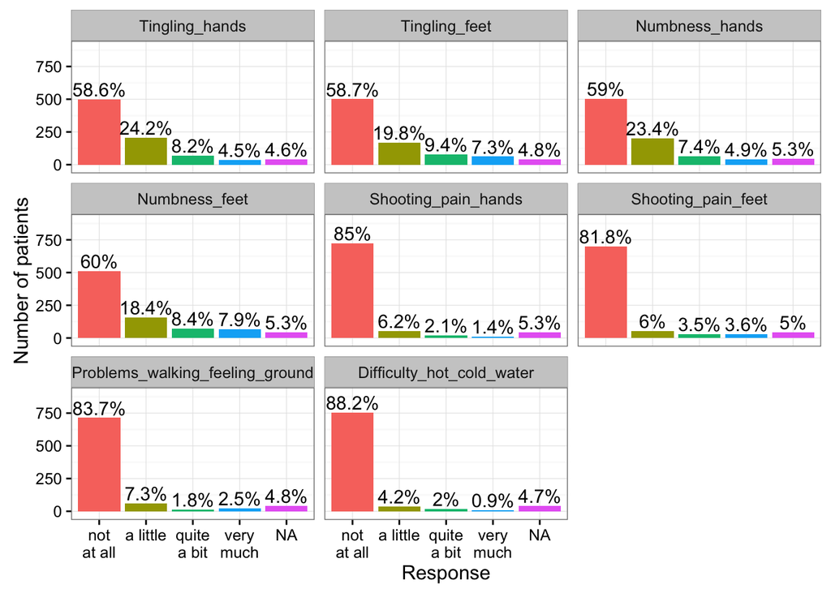

```r
fam <- read.table(my.dir %&% "genotypes/N88.forImputation.fam")
colnames(fam) <- c("FID","patno","father","mother","sex","pheno")
fam <- fam %>% mutate(IID=as.character(patno))
demog <- read.sas7bdat(pheno.dir %&% "demographics.sas7bdat")
cipn8sens <- demog %>% dplyr::select(patno, agediagnosis, C_Q15ARSP, C_Q15BRSP, C_Q15CRSP, C_Q15DRSP, C_Q15ERSP, C_Q15FRSP, C_Q15IRSP, C_Q15JRSP) %>% rename(Tingling_hands=C_Q15ARSP, Tingling_feet=C_Q15BRSP, Numbness_hands=C_Q15CRSP, Numbness_feet=C_Q15DRSP, Shooting_pain_hands=C_Q15ERSP, Shooting_pain_feet=C_Q15FRSP, Problems_walking_feeling_ground=C_Q15IRSP, Difficulty_hot_cold_water=C_Q15JRSP)

##Plot responses
a<-cipn8sens
ga <- gather(a,question,response,-patno, -agediagnosis)
ggplot(ga,aes(x=factor(response,labels=c("not\nat all","a little","quite\na bit","very\nmuch","NA")), fill=factor(response)))+geom_bar()+facet_wrap(~question)+xlab("Response")+geom_text(aes(y = (..count..),label = paste(round(ifelse((..count..)==0,"",8*((..count..)/sum(..count..)))*100,1),"%",sep="")), stat="count",vjust=-0.25,size=4)+guides(fill=FALSE)+theme_bw()+ylab("Number of patients")+coord_cartesian(ylim=c(-20,900))
```

```r
##Calculate Cronbach's alpha
CIPN20_8sens <- cipn8sens[,3:10]
psych::alpha(CIPN20_8sens)$total
```

```
##  raw_alpha std.alpha   G6(smc) average_r      S/N        ase     mean
##  0.8820352 0.8855303 0.9080124 0.4916096 7.735939 0.01236457 0.389312
##         sd
##  0.5604279
```

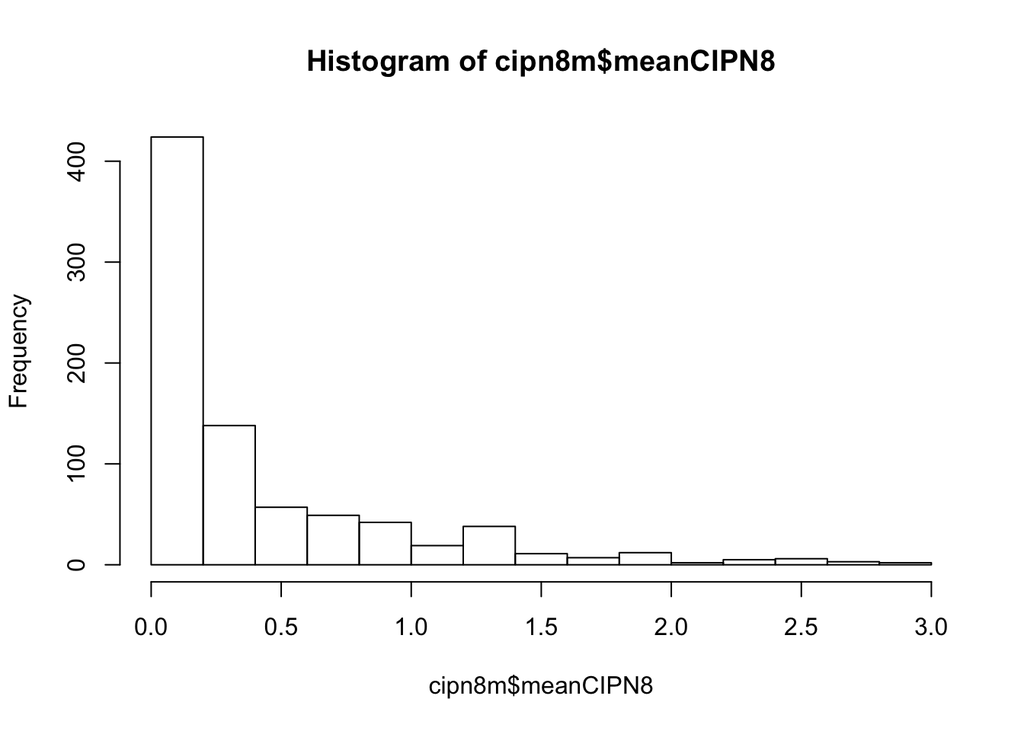

```r
cipn8m <- dplyr::select(cipn8sens,patno,agediagnosis) %>% mutate(IID=as.character(patno),meanCIPN8=rowMeans(CIPN20_8sens,na.rm=TRUE))
hist(cipn8m$meanCIPN8)
```

```r
table(cipn8m$meanCIPN8==0)
```

```
##
## FALSE  TRUE
##   461   354
```

```r
table(ceiling(cipn8m$meanCIPN8))
```

```
##
##   0   1   2   3
## 354 356  87  18
```

```r
table(ceiling(cipn8m$meanCIPN8))/sum(table(ceiling(cipn8m$meanCIPN8)))
```

```
##
##          0          1          2          3
## 0.43435583 0.43680982 0.10674847 0.02208589
```

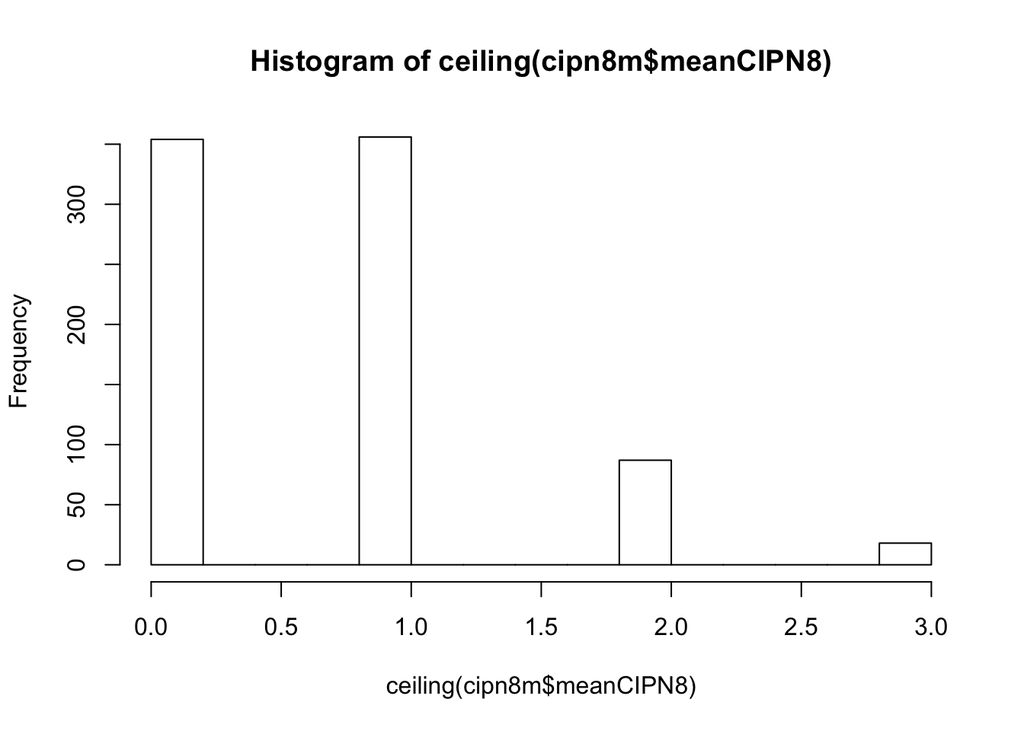

```r
hist(ceiling(cipn8m$meanCIPN8))
```

```r
##ordCIPN8 groups: meanCIPN8: 0, 0<x<=1, 1<x<=2, 2<x<=3
##biCIPN8: meanCIPN8=0, >0
##exCIPN8: meanCIPN8=0 vs 2or3
##ord3CIPN8 groups: meanCIPN8: 0, 0<x<=1, 1<x<=3
cipn8m <- dplyr::select(cipn8m,IID,agediagnosis,meanCIPN8) %>% mutate(ordCIPN8=ceiling(meanCIPN8),biCIPN8=ifelse(meanCIPN8==0,0,1)) %>% mutate(ord3CIPN8=ifelse(ordCIPN8==3,2,ordCIPN8))
exCIPN8 <- ifelse(cipn8m$ordCIPN8==1,NA,cipn8m$ordCIPN8)
exCIPN8 <- ifelse(exCIPN8>=2,1,exCIPN8)
cipn8m <- cipn8m %>% mutate(exCIPN8=exCIPN8)
table(cipn8m$exCIPN8)
```

```
##
##   0   1
## 354 105
```

```r
table(cipn8m$ord3CIPN8)
```

```
##
##   0   1   2
## 354 356 105
```

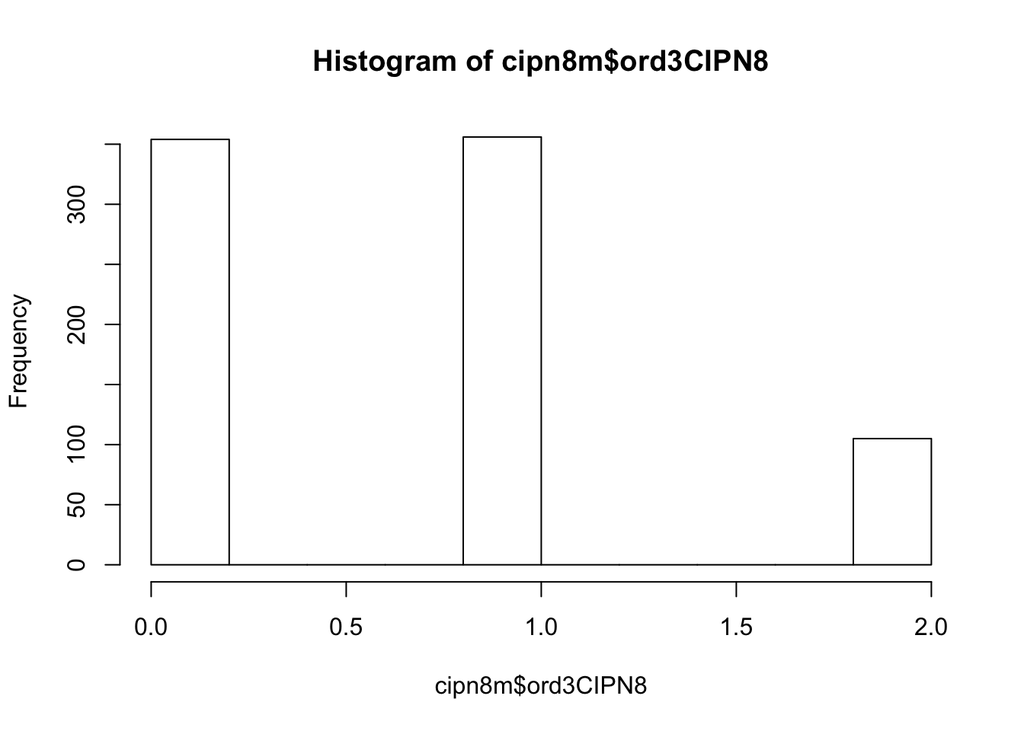

```r
hist(cipn8m$ord3CIPN8)
```

```r
head(cipn8m)
```

```
##     IID agediagnosis meanCIPN8 ordCIPN8 biCIPN8 ord3CIPN8 exCIPN8
## 1 30000         36.2     0.000        0       0         0       0
## 2 30001         24.0     0.000        0       0         0       0
## 3 30002         31.1     0.750        1       1         1      NA
## 4 30003         49.0     0.375        1       1         1      NA
## 5 30004         25.1     0.125        1       1         1      NA
## 6 30005         30.8     0.625        1       1         1      NA
```

```r
dim(cipn8m)
```

```
## [1] 853   7
```

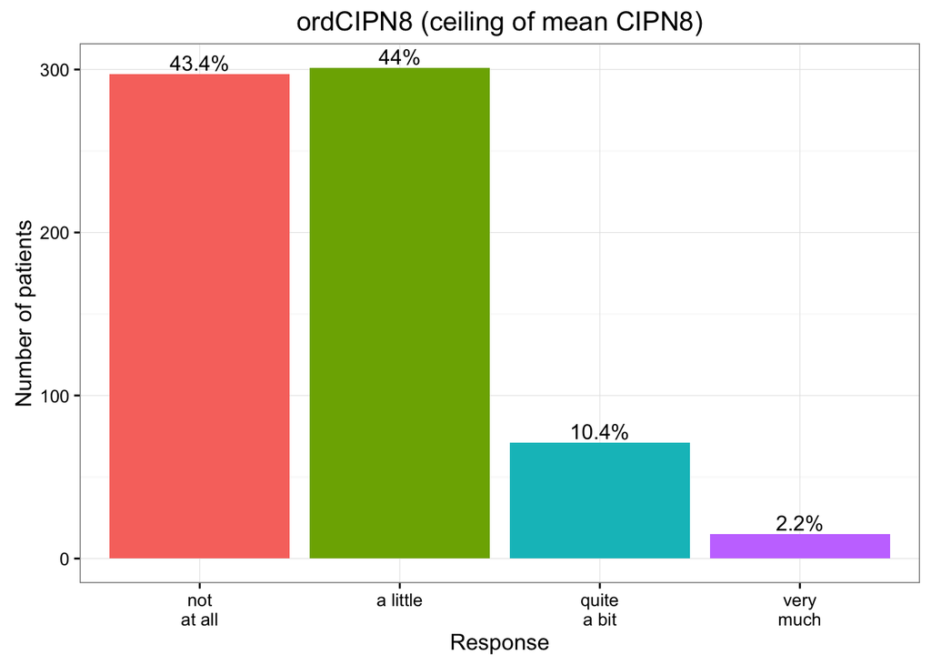

```r
patcipn <- left_join(fam,cipn8m,by="IID") %>% dplyr::select(FID,IID,meanCIPN8,ordCIPN8,biCIPN8,exCIPN8,ord3CIPN8,agediagnosis)

write.table(patcipn,file=my.dir %&% "genotypes/PtStudy.CIPN8.phenofile",quote=F,row.names = F,col.names = T)

nona.patcipn <- patcipn[is.na(patcipn$ordCIPN8)==FALSE,]
ggplot(nona.patcipn,aes(x=factor(ordCIPN8,labels=c("not\nat all","a little","quite\na bit","very\nmuch")), fill=factor(ordCIPN8)))+geom_bar()+xlab("Response")+geom_text(aes(y = (..count..),label = paste(round(ifelse((..count..)==0,"",((..count..)/sum(..count..)))*100,1),"%",sep="")), stat="count",vjust=-0.25,size=4)+guides(fill=FALSE)+theme_bw()+ylab("Number of patients")+ggtitle('ordCIPN8 (ceiling of mean CIPN8)')
```

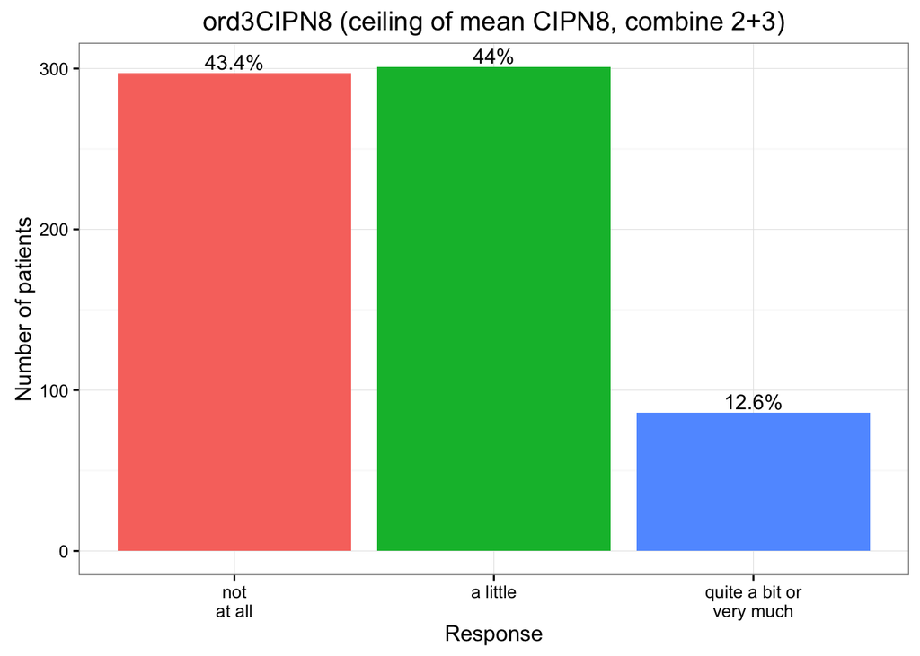

```r
ggplot(nona.patcipn,aes(x=factor(ord3CIPN8,labels=c("not\nat all","a little","quite a bit or\nvery much")), fill=factor(ord3CIPN8)))+geom_bar()+xlab("Response")+geom_text(aes(y = (..count..),label = paste(round(ifelse((..count..)==0,"",((..count..)/sum(..count..)))*100,1),"%",sep="")), stat="count",vjust=-0.25,size=4)+guides(fill=FALSE)+theme_bw()+ylab("Number of patients")+ggtitle('ord3CIPN8 (ceiling of mean CIPN8, combine 2+3)')
```

```r
summary(lm(patcipn$agediagnosis~patcipn$ordCIPN8))$coef
```

```
##                   Estimate Std. Error   t value      Pr(>|t|)
## (Intercept)      30.226672  0.4393118 68.804604 2.999357e-307
## patcipn$ordCIPN8  2.311525  0.4292833  5.384613  1.003264e-07
```

```r
summary(lm(patcipn$agediagnosis~patcipn$ordCIPN8))$r.squared
```

```
## [1] 0.04118509
```

```r
#number nonmissing ordCIPN8 phenotypes (TRUE):
table(is.na(patcipn$ordCIPN8)==FALSE)
```

```
##
## FALSE  TRUE
##   269   684
```

```r
#number nonmissing exCIPN8 phenotypes (TRUE):
table(is.na(patcipn$exCIPN8)==FALSE)
```

```
##
## FALSE  TRUE
##   570   383
```

```r
phenCombo <- left_join(phenCombo,patcipn,by="IID")
phenCombo <- left_join(phenCombo,patcov,by="IID")
phenEric <- phenCombo %>% dplyr::select(FID.x, IID, GM412, rnGM412, logGM412, QUARTILE ,meanCIPN8,ordCIPN8,biCIPN8,ord3CIPN8,exCIPN8,ageaudio.x,agediagnosis,CumlCispdose,CumlBLEOdose) %>% dplyr::rename(FID=FID.x,quartile=QUARTILE,ageaudio=ageaudio.x)
phentable <- phenEric %>% mutate(CumlBLEOdose=ifelse(is.nan(CumlBLEOdose),NA,CumlBLEOdose)) #should any CumlBLEOdose == 0? Check before Raynaud's GWAS
```

test run:  
`plink --bfile N88.forImputation --1 --pheno PtStudy.CIPN8.phenofile --pheno-name biCIPN8 --logistic --adjust --covar PtStudy.covfile --out PtStudy.preImpute.2015-11-24.biCIPN8ageaudio.Cispdose`

`plink --bfile N88.forImputation --1 --pheno PtStudy.CIPN8.phenofile --pheno-name exCIPN8 --logistic --adjust --covar PtStudy.covfile --out PtStudy.preImpute.2015-11-24.exCIPN8ageaudio.Cispdose`

`plink --bfile N88.forImputation --1 --pheno PtStudy.CIPN8.phenofile --pheno-name biCIPN8 --logistic --adjust --covar PtStudy.covfile --covar-name ageaudio --out PtStudy.preImpute.2015-11-24.biCIPN8ageaudio`

`plink --bfile N88.forImputation --1 --pheno PtStudy.CIPN8.phenofile --pheno-name exCIPN8 --logistic --adjust --covar PtStudy.covfile --covar-name ageaudio --out PtStudy.preImpute.2015-11-24.exCIPN8ageaudio`

#### TO DO: code for ordinal regression phenotypes–>see 14_ordreg_GWAS.R

### Does ordCIPN8 associate with agediagnosis? CumlCispdose?

- only agediagnosis is signficant:

```r
phenofile <- ptcov.dir %&% "PtStudy.phenofile"
covfile <- ptcov.dir %&% "PtStudy.covfile"
pheno <- read.table(phenofile,header=T)
cov <- read.table(covfile,header=T) %>% dplyr::select(FID,starts_with("PC"))
pheno <- left_join(pheno,cov,by="FID")

#ordCIPN8 ~ agediagnosis
m<-polr(factor(pheno$ordCIPN8) ~ pheno$agediagnosis, Hess=TRUE)
p <- pnorm(abs(summary(m)$coefficients[, "t value"]), lower.tail = FALSE) * 2
or <- exp(summary(m)$coefficients[,"Value"])
ci <- exp(confint.default(m))
colnames(ci) <- c("lCI","uCI")
res <- cbind(summary(m)$coefficients[,],"OR"=or,"pval"=p)[1,]
res <- c(res, ci[1,])
res
```

```
##        Value   Std. Error      t value           OR         pval
## 5.219153e-02 8.992733e-03 5.803744e+00 1.053578e+00 6.485009e-09
##          lCI          uCI
## 1.035170e+00 1.072312e+00
```

```r
#ordCIPN8 ~ CumlCispdose
m<-polr(factor(pheno$ordCIPN8) ~ pheno$CumlCispdose, Hess=TRUE)
p <- pnorm(abs(summary(m)$coefficients[, "t value"]), lower.tail = FALSE) * 2
or <- exp(summary(m)$coefficients[,"Value"])
ci <- exp(confint.default(m))
colnames(ci) <- c("lCI","uCI")
res <- cbind(summary(m)$coefficients[,],"OR"=or,"pval"=p)[1,]
res <- c(res, ci[1,])
res
```

```
##        Value   Std. Error      t value           OR         pval
## 0.0003613255 0.0009651703 0.3743645539 1.0003613908 0.7081331107
##          lCI          uCI
## 0.9984707970 1.0022555645
```

```r
#ordCIPN8 ~ agediagnosis + CumlCispdose
m<-polr(factor(pheno$ordCIPN8) ~ pheno$agediagnosis + pheno$CumlCispdose, Hess=TRUE)
p <- pnorm(abs(summary(m)$coefficients[, "t value"]), lower.tail = FALSE) * 2
or <- exp(summary(m)$coefficients[,"Value"])
ci <- exp(confint.default(m))
colnames(ci) <- c("lCI","uCI")
res <- cbind(summary(m)$coefficients[,],"OR"=or,"pval"=p)
res <- cbind(res[1:2,],ci)
res
```

```
##                           Value   Std. Error   t value       OR
## pheno$agediagnosis 0.0541023131 0.0090608353 5.9710072 1.055593
## pheno$CumlCispdose 0.0006055418 0.0009770541 0.6197628 1.000606
##                            pval       lCI      uCI
## pheno$agediagnosis 2.357933e-09 1.0370119 1.074506
## pheno$CumlCispdose 5.354140e-01 0.9986914 1.002524
```

```r
#ordCIPN8 ~ agediagnosis + 10 PCs
covmat <- dplyr::select(pheno,agediagnosis,starts_with("PC"))
covmat <- as.matrix(covmat)
m<-polr(factor(pheno$ordCIPN8) ~ covmat, Hess=TRUE)
p <- pnorm(abs(summary(m)$coefficients[, "t value"]), lower.tail = FALSE) * 2
or <- exp(summary(m)$coefficients[,"Value"])
ci <- exp(confint.default(m))
colnames(ci) <- c("lCI","uCI")
res <- cbind(summary(m)$coefficients[,],"OR"=or,"pval"=p)
res <- cbind(res[1:dim(covmat)[2],], ci)
res
```

```
##                          Value Std. Error    t value          OR
## covmatagediagnosis  0.05409088 0.00912303  5.9290475  1.05558053
## covmatPC1           3.06009300 2.38263177  1.2843332 21.32954065
## covmatPC2           1.65098699 2.26004982  0.7305091  5.21212160
## covmatPC3          -1.06470892 2.33339595 -0.4562916  0.34482821
## covmatPC4          -0.73083353 2.29884538 -0.3179133  0.48150747
## covmatPC5           3.05079138 2.27574959  1.3405655 21.13206122
## covmatPC6          -2.69510064 2.28179410 -1.1811323  0.06753558
## covmatPC7           2.77250069 2.30796714  1.2012739 15.99859150
## covmatPC8          -3.71082114 2.39442792 -1.5497736  0.02445743
## covmatPC9          -0.61251230 2.35446936 -0.2601488  0.54198752
## covmatPC10         -0.67669857 2.30426458 -0.2936723  0.50829232
##                            pval          lCI         uCI
## covmatagediagnosis 3.046969e-09 1.0368736377    1.074625
## covmatPC1          1.990254e-01 0.1999317024 2275.523586
## covmatPC2          4.650790e-01 0.0621236045  437.292906
## covmatPC3          6.481803e-01 0.0035596931   33.403581
## covmatPC4          7.505507e-01 0.0053189058   43.589688
## covmatPC5          1.800616e-01 0.2442419739 1828.367189
## covmatPC6          2.375502e-01 0.0007713758    5.912884
## covmatPC7          2.296450e-01 0.1735947402 1474.439432
## covmatPC8          1.211959e-01 0.0002240114    2.670248
## covmatPC9          7.947490e-01 0.0053686036   54.716365
## covmatPC10         7.690084e-01 0.0055554594   46.505799
```

```r
#ordCIPN8 ~ agediagnosis + CumlCispdose + 10 PCs
covmat <- dplyr::select(pheno,agediagnosis,CumlCispdose,starts_with("PC"))
covmat <- as.matrix(covmat)
m<-polr(factor(pheno$ordCIPN8) ~ covmat, Hess=TRUE)
p <- pnorm(abs(summary(m)$coefficients[, "t value"]), lower.tail = FALSE) * 2
or <- exp(summary(m)$coefficients[,"Value"])
ci <- exp(confint.default(m))
colnames(ci) <- c("lCI","uCI")
res <- cbind(summary(m)$coefficients[,],"OR"=or,"pval"=p)
res <- cbind(res[1:dim(covmat)[2],], ci)
res
```

```
##                            Value   Std. Error       t value          OR
## covmatagediagnosis  0.0560260971 0.0091218685     6.1419540  1.05762528
## covmatCumlCispdose  0.0005701399 0.0009795277     0.5820559  1.00057030
## covmatPC1           2.9183805453 0.0056291343   518.4421570 18.51128499
## covmatPC2           1.4692314242 0.0017274252   850.5325664  4.34589371
## covmatPC3          -1.6432062631 0.0044280669  -371.0888552  0.19335909
## covmatPC4          -0.4493842889 0.0020992133  -214.0727149  0.63802087
## covmatPC5           2.8815709804 0.0037765208   763.0226612 17.84228105
## covmatPC6          -2.7286532801 0.0041948285  -650.4802886  0.06530718
## covmatPC7           2.8590234502 0.0005522160  5177.3648280 17.44448321
## covmatPC8          -3.6063635619 0.0029058175 -1241.0839846  0.02715040
## covmatPC9          -0.6342790601 0.0010335050  -613.7164620  0.53031768
## covmatPC10         -0.7707624172 0.0011895832  -647.9264252  0.46266019
##                            pval         lCI         uCI
## covmatagediagnosis 8.151245e-10  1.03888452  1.07670412
## covmatCumlCispdose 5.605290e-01  0.99865121  1.00249308
## covmatPC1          0.000000e+00 18.30817433 18.71664895
## covmatPC2          0.000000e+00  4.33120473  4.36063250
## covmatPC3          0.000000e+00  0.19168821  0.19504453
## covmatPC4          0.000000e+00  0.63540120  0.64065134
## covmatPC5          0.000000e+00 17.71070281 17.97483682
## covmatPC6          0.000000e+00  0.06477245  0.06584633
## covmatPC7          0.000000e+00 17.42561285 17.46337400
## covmatPC8          0.000000e+00  0.02699621  0.02730547
## covmatPC9          0.000000e+00  0.52924454  0.53139300
## covmatPC10         0.000000e+00  0.46158274  0.46374016
```

### Pull SCIN

- Tinnitus: ordTin (C_Q27ERSP)
- Reduced Hearing: ordHL (C_Q27FRSP)
- Raynaud’s: ordRay (mean C_Q27CRSP & C_Q27DRSP, take ceiling)
- also pull CumlBLEOdose
- add to PtStudy.phenofile

```r
fam <- read.table(my.dir %&% "genotypes/N88.forImputation.fam")
colnames(fam) <- c("FID","patno","father","mother","sex","pheno")
fam <- fam %>% mutate(IID=as.character(patno))
demog <- read.sas7bdat(pheno.dir %&% "demographics.sas7bdat")
scin <- demog %>% dplyr::select(patno,C_Q27ARSP,C_Q27BRSP,C_Q27CRSP,C_Q27DRSP,C_Q27ERSP,C_Q27FRSP) %>% rename(Pain_Tingling_Feet=C_Q27ARSP,Pain_Tingling_Hands=C_Q27BRSP,White_Cold_Hands=C_Q27CRSP,White_Cold_Feet=C_Q27DRSP,ordTin=C_Q27ERSP,ordHL=C_Q27FRSP)
a<-scin
dim(a)
```

```
## [1] 853   7
```

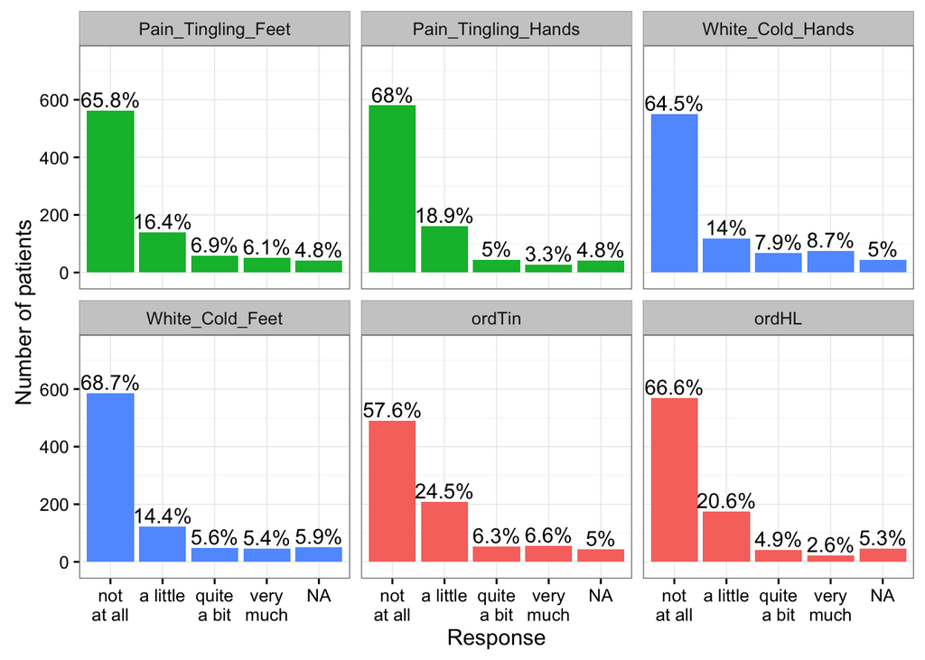

```r
##Plot responses
ga <- gather(a,question,response,-patno)
ga <- ga %>% mutate(type=ifelse(question=="Pain_Tingling_Feet" | question=="Pain_Tingling_Hands","parathesias",question)) %>% mutate(type=ifelse(type<=4,"Raynaud",type)) %>% mutate(type=ifelse(type<=6,"ototoxicity",type))
ggplot(ga,aes(x=factor(response,labels=c("not\nat all","a little","quite\na bit","very\nmuch","NA")),fill=type))+geom_bar()+facet_wrap(~question)+xlab("Response")+geom_text(aes(y = (..count..),label = paste(round(ifelse((..count..)==0,"",6*((..count..)/sum(..count..)))*100,1),"%",sep="")), stat="count",vjust=-0.25,size=4)+guides(fill=FALSE)+theme_bw()+ylab("Number of patients")+coord_cartesian(ylim=c(-20,750))
```

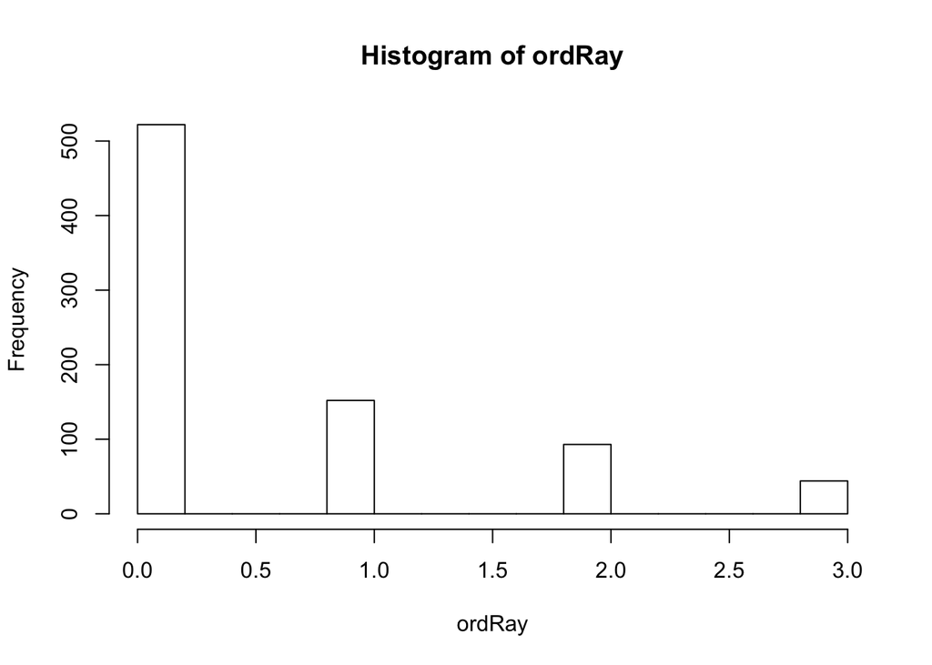

```r
ray <- dplyr::select(scin,White_Cold_Hands,White_Cold_Feet)
ordRay <- ceiling(rowMeans(ray,na.rm=TRUE))
hist(ordRay)
```

```r
table(ordRay)/sum(table(ordRay))
```

```
## ordRay
##          0          1          2          3
## 0.64364982 0.18742293 0.11467324 0.05425401
```

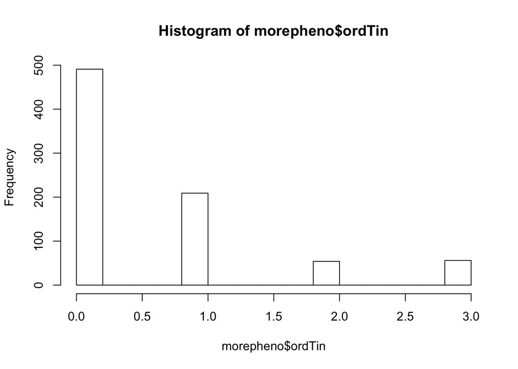

```r
morepheno <- dplyr::select(scin,patno,ordTin,ordHL) %>% mutate(IID=as.character(patno),ordRay=ordRay)
hist(morepheno$ordTin)
```

```r
table(morepheno$ordTin)/sum(table(morepheno$ordTin))
```

```
##
##          0          1          2          3
## 0.60617284 0.25802469 0.06666667 0.06913580
```

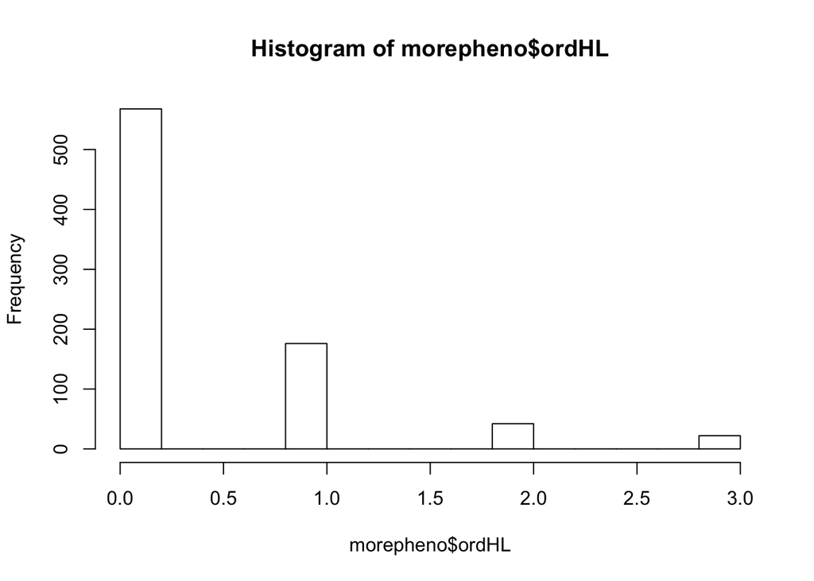

```r
hist(morepheno$ordHL)
```

```r
table(morepheno$ordHL)/sum(table(morepheno$ordHL))
```

```
##
##          0          1          2          3
## 0.70297030 0.21782178 0.05198020 0.02722772
```

```r
phentable2<-left_join(phentable,morepheno,by="IID")
write.table(phentable2,file=my.dir %&% "genotypes/PtStudy.phenofile",quote=F,row.names = F,col.names = T)
```

### Do ordTin and ordHL associate with agediagnosis? CumlCispdose?

```r
phenofile <- ptcov.dir %&% "PtStudy.phenofile"
covfile <- ptcov.dir %&% "PtStudy.covfile"
pheno <- read.table(phenofile,header=T)
cov <- read.table(covfile,header=T) %>% dplyr::select(FID,starts_with("PC"))
pheno <- left_join(pheno,cov,by="FID")

#ordTin ~ agediagnosis
m<-polr(factor(pheno$ordTin) ~ pheno$agediagnosis, Hess=TRUE)
p <- pnorm(abs(summary(m)$coefficients[, "t value"]), lower.tail = FALSE) * 2
or <- exp(summary(m)$coefficients[,"Value"])
ci <- exp(confint.default(m))
colnames(ci) <- c("lCI","uCI")
res <- cbind(summary(m)$coefficients[,],"OR"=or,"pval"=p)[1,]
res <- c(res, ci[1,])
res
```

```
##       Value  Std. Error     t value          OR        pval         lCI
## 0.014547411 0.009179658 1.584744319 1.014653739 0.113024438 0.996561537
##         uCI
## 1.033074399
```

```r
#ordTin ~ CumlCispdose
m<-polr(factor(pheno$ordTin) ~ pheno$CumlCispdose, Hess=TRUE)
p <- pnorm(abs(summary(m)$coefficients[, "t value"]), lower.tail = FALSE) * 2
or <- exp(summary(m)$coefficients[,"Value"])
ci <- exp(confint.default(m))
colnames(ci) <- c("lCI","uCI")
res <- cbind(summary(m)$coefficients[,],"OR"=or,"pval"=p)[1,]
res <- c(res, ci[1,])
res
```

```
##        Value   Std. Error      t value           OR         pval
## 0.0015504641 0.0009919877 1.5629871951 1.0015516667 0.1180556067
##          lCI          uCI
## 0.9996062814 1.0035008379
```

```r
#ordTin ~ agediagnosis + CumlCispdose
m<-polr(factor(pheno$ordTin) ~ pheno$agediagnosis + pheno$CumlCispdose, Hess=TRUE)
p <- pnorm(abs(summary(m)$coefficients[, "t value"]), lower.tail = FALSE) * 2
or <- exp(summary(m)$coefficients[,"Value"])
ci <- exp(confint.default(m))
colnames(ci) <- c("lCI","uCI")
res <- cbind(summary(m)$coefficients[,],"OR"=or,"pval"=p)
res <- cbind(res[1:2,],ci)
res
```

```
##                          Value   Std. Error  t value       OR       pval
## pheno$agediagnosis 0.015858649 0.0092322724 1.717741 1.015985 0.08584395
## pheno$CumlCispdose 0.001618063 0.0009928088 1.629783 1.001619 0.10314746
##                          lCI      uCI
## pheno$agediagnosis 0.9977662 1.034537
## pheno$CumlCispdose 0.9996722 1.003570
```

```r
#ordTin ~ agediagnosis + 10 PCs
covmat <- dplyr::select(pheno,agediagnosis,starts_with("PC"))
covmat <- as.matrix(covmat)
m<-polr(factor(pheno$ordTin) ~ covmat, Hess=TRUE)
p <- pnorm(abs(summary(m)$coefficients[, "t value"]), lower.tail = FALSE) * 2
or <- exp(summary(m)$coefficients[,"Value"])
ci <- exp(confint.default(m))
colnames(ci) <- c("lCI","uCI")
res <- cbind(summary(m)$coefficients[,],"OR"=or,"pval"=p)
res <- cbind(res[1:dim(covmat)[2],], ci)
res
```

```
##                          Value  Std. Error    t value          OR
## covmatagediagnosis  0.01667452 0.009247118  1.8032129  1.01681432
## covmatPC1          -0.29263679 2.412372906 -0.1213066  0.74629315
## covmatPC2           3.45405222 2.353985155  1.4673212 31.62829776
## covmatPC3          -3.48043985 2.389246336 -1.4567103  0.03079386
## covmatPC4           1.10682384 2.378644621  0.4653170  3.02473606
## covmatPC5           4.36609008 2.391741357  1.8254859 78.73518048
## covmatPC6           2.35888323 2.378485626  0.9917585 10.57913040
## covmatPC7           1.85352959 2.406274642  0.7702901  6.38230673
## covmatPC8           1.19836640 2.455432282  0.4880470  3.31469760
## covmatPC9          -1.53737994 2.403073085 -0.6397558  0.21494353
## covmatPC10         -1.10461779 2.398014868 -0.4606384  0.33133750
##                          pval          lCI         uCI
## covmatagediagnosis 0.07135478 0.9985515545    1.035411
## covmatPC1          0.90344818 0.0065992399   84.396609
## covmatPC2          0.14228871 0.3135884236 3190.006850
## covmatPC3          0.14519635 0.0002849273    3.328085
## covmatPC4          0.64170445 0.0285746890  320.179452
## covmatPC5          0.06792774 0.7249614159 8551.115286
## covmatPC6          0.32131537 0.0999722197 1119.490999
## covmatPC7          0.44112781 0.0571153686  713.185264
## covmatPC8          0.62551654 0.0269386710  407.860514
## covmatPC9          0.52233137 0.0019356412   23.868432
## covmatPC10         0.64505804 0.0030135377   36.430451
```

```r
#ordTin ~ agediagnosis + CumlCispdose + 10 PCs
covmat <- dplyr::select(pheno,agediagnosis,CumlCispdose,starts_with("PC"))
covmat <- as.matrix(covmat)
m<-polr(factor(pheno$ordTin) ~ covmat, Hess=TRUE)
p <- pnorm(abs(summary(m)$coefficients[, "t value"]), lower.tail = FALSE) * 2
or <- exp(summary(m)$coefficients[,"Value"])
ci <- exp(confint.default(m))
colnames(ci) <- c("lCI","uCI")
res <- cbind(summary(m)$coefficients[,],"OR"=or,"pval"=p)
res <- cbind(res[1:dim(covmat)[2],], ci)
res
```

```
##                           Value   Std. Error      t value          OR
## covmatagediagnosis  0.018226905 9.246844e-03     1.971149  1.01839403
## covmatCumlCispdose  0.001290586 9.982399e-04     1.292862  1.00129142
## covmatPC1          -0.083818366 3.850199e-03   -21.769878  0.91959827
## covmatPC2           3.638044216 6.874156e-04  5292.350117 38.01741014
## covmatPC3          -3.912310601 2.640849e-03 -1481.459180  0.01999425
## covmatPC4           1.391351732 3.854749e-04  3609.448467  4.02028073
## covmatPC5           4.048275793 5.317547e-03   761.305079 57.29857722
## covmatPC6           2.192000533 7.479613e-04  2930.633638  8.95310620
## covmatPC7           2.120794890 9.662065e-05 21949.706820  8.33776246
## covmatPC8           1.354775573 1.629028e-03   831.646779  3.87589100
## covmatPC9          -1.541092825 4.010523e-04 -3842.623515  0.21414695
## covmatPC10         -1.401667838 3.796160e-03  -369.233057  0.24618602
##                             pval         lCI         uCI
## covmatagediagnosis  4.870686e-02  1.00010343  1.03701914
## covmatCumlCispdose  1.960588e-01  0.99933429  1.00325238
## covmatPC1          4.478180e-105  0.91268487  0.92656404
## covmatPC2           0.000000e+00 37.96622340 38.06866590
## covmatPC3           0.000000e+00  0.01989103  0.02009801
## covmatPC4           0.000000e+00  4.01724448  4.02331926
## covmatPC5           0.000000e+00 56.70450108 57.89887731
## covmatPC6           0.000000e+00  8.93999076  8.96624087
## covmatPC7           0.000000e+00  8.33618366  8.33934156
## covmatPC8           0.000000e+00  3.86353566  3.88828586
## covmatPC9           0.000000e+00  0.21397868  0.21431534
## covmatPC10          0.000000e+00  0.24436111  0.24802456
```

```r
#ordHL ~ agediagnosis
m<-polr(factor(pheno$ordHL) ~ pheno$agediagnosis, Hess=TRUE)
p <- pnorm(abs(summary(m)$coefficients[, "t value"]), lower.tail = FALSE) * 2
or <- exp(summary(m)$coefficients[,"Value"])
ci <- exp(confint.default(m))
colnames(ci) <- c("lCI","uCI")
res <- cbind(summary(m)$coefficients[,],"OR"=or,"pval"=p)[1,]
res <- c(res, ci[1,])
res
```

```
##       Value  Std. Error     t value          OR        pval         lCI
## 0.024686626 0.009675979 2.551331079 1.024993864 0.010731233 1.005738458
##         uCI
## 1.044617925
```

```r
#ordHL ~ CumlCispdose
m<-polr(factor(pheno$ordHL) ~ pheno$CumlCispdose, Hess=TRUE)
p <- pnorm(abs(summary(m)$coefficients[, "t value"]), lower.tail = FALSE) * 2
or <- exp(summary(m)$coefficients[,"Value"])
ci <- exp(confint.default(m))
colnames(ci) <- c("lCI","uCI")
res <- cbind(summary(m)$coefficients[,],"OR"=or,"pval"=p)[1,]
res <- c(res, ci[1,])
res
```

```
##       Value  Std. Error     t value          OR        pval         lCI
## 0.001329865 0.001050092 1.266426977 1.001330750 0.205360258 0.999271987
##         uCI
## 1.003393753
```

```r
#ordHL ~ agediagnosis + CumlCispdose
m<-polr(factor(pheno$ordHL) ~ pheno$agediagnosis + pheno$CumlCispdose, Hess=TRUE)
p <- pnorm(abs(summary(m)$coefficients[, "t value"]), lower.tail = FALSE) * 2
or <- exp(summary(m)$coefficients[,"Value"])
ci <- exp(confint.default(m))
colnames(ci) <- c("lCI","uCI")
res <- cbind(summary(m)$coefficients[,],"OR"=or,"pval"=p)
res <- cbind(res[1:2,],ci)
res
```

```
##                          Value  Std. Error  t value       OR        pval
## pheno$agediagnosis 0.025560132 0.009748669 2.621910 1.025890 0.008743852
## pheno$CumlCispdose 0.001477022 0.001056450 1.398099 1.001478 0.162083200
##                          lCI      uCI
## pheno$agediagnosis 1.0064740 1.045680
## pheno$CumlCispdose 0.9994066 1.003554
```

```r
#ordHL ~ agediagnosis + 10 PCs
covmat <- dplyr::select(pheno,agediagnosis,starts_with("PC"))
covmat <- as.matrix(covmat)
m<-polr(factor(pheno$ordHL) ~ covmat, Hess=TRUE)
p <- pnorm(abs(summary(m)$coefficients[, "t value"]), lower.tail = FALSE) * 2
or <- exp(summary(m)$coefficients[,"Value"])
ci <- exp(confint.default(m))
colnames(ci) <- c("lCI","uCI")
res <- cbind(summary(m)$coefficients[,],"OR"=or,"pval"=p)
res <- cbind(res[1:dim(covmat)[2],], ci)
res
```

```
##                          Value  Std. Error     t value         OR
## covmatagediagnosis  0.02477641 0.009727693  2.54699756 1.02508590
## covmatPC1          -0.77502945 2.565317671 -0.30211831 0.46069021
## covmatPC2          -0.61611097 2.506991497 -0.24575711 0.54004059
## covmatPC3          -1.60557443 2.537192115 -0.63281548 0.20077419
## covmatPC4           0.10279735 2.536195298  0.04053211 1.10826679
## covmatPC5           0.65940104 2.478132708  0.26608786 1.93363381
## covmatPC6          -0.35915619 2.551985786 -0.14073597 0.69826528
## covmatPC7           2.01611794 2.552297921  0.78992265 7.50911740
## covmatPC8           0.80577825 2.606962416  0.30908702 2.23843788
## covmatPC9          -3.80764222 2.572939767 -1.47988004 0.02220046
## covmatPC10         -0.88792000 2.573305785 -0.34505033 0.41151081
##                          pval          lCI         uCI
## covmatagediagnosis 0.01086542 1.0057268185    1.044818
## covmatPC1          0.76256187 0.0030186074   70.309069
## covmatPC2          0.80587026 0.0039670838   73.515927
## covmatPC3          0.52685415 0.0013901000   28.998112
## covmatPC4          0.96766891 0.0076883115  159.756182
## covmatPC5          0.79017154 0.0150308606  248.750875
## covmatPC6          0.88807853 0.0046964122  103.818486
## covmatPC7          0.42957294 0.0504741443 1117.143142
## covmatPC8          0.75725533 0.0135174451  370.676862
## covmatPC9          0.13890526 0.0001433084    3.439159
## covmatPC10         0.73005654 0.0026544796   63.794480
```

```r
#ordHL ~ agediagnosis + CumlCispdose + 10 PCs
covmat <- dplyr::select(pheno,agediagnosis,CumlCispdose,starts_with("PC"))
covmat <- as.matrix(covmat)
m<-polr(factor(pheno$ordHL) ~ covmat, Hess=TRUE)
p <- pnorm(abs(summary(m)$coefficients[, "t value"]), lower.tail = FALSE) * 2
or <- exp(summary(m)$coefficients[,"Value"])
ci <- exp(confint.default(m))
colnames(ci) <- c("lCI","uCI")
res <- cbind(summary(m)$coefficients[,],"OR"=or,"pval"=p)
res <- cbind(res[1:dim(covmat)[2],], ci)
res
```

```
##                          Value   Std. Error      t value        OR
## covmatagediagnosis  0.02559392 0.0097560057     2.623401 1.0259243
## covmatCumlCispdose  0.00144445 0.0010608260     1.361627 1.0014455
## covmatPC1          -0.96217307 0.0070769572  -135.958583 0.3820617
## covmatPC2          -0.91956155 0.0028053417  -327.789495 0.3986938
## covmatPC3          -1.99293485 0.0044081245  -452.104937 0.1362948
## covmatPC4           0.09217922 0.0011141346    82.736160 1.0965613
## covmatPC5           0.59895802 0.0075934364    78.878388 1.8202212
## covmatPC6          -0.45391404 0.0017215143  -263.671373 0.6351373
## covmatPC7           1.80127968 0.0015098255  1193.038303 6.0573940
## covmatPC8           0.91361830 0.0017001009   537.390637 2.4933278
## covmatPC9          -3.89670075 0.0006524097 -5972.781683 0.0203088
## covmatPC10         -0.52431868 0.0016738753  -313.236411 0.5919585
##                           pval        lCI        uCI
## covmatagediagnosis 0.008705665 1.00649349 1.04573014
## covmatCumlCispdose 0.173315492 0.99936547 1.00352985
## covmatPC1          0.000000000 0.37679890 0.38739808
## covmatPC2          0.000000000 0.39650766 0.40089202
## covmatPC3          0.000000000 0.13512235 0.13747749
## covmatPC4          0.000000000 1.09416942 1.09895847
## covmatPC5          0.000000000 1.79333167 1.84751387
## covmatPC6          0.000000000 0.63299792 0.63728397
## covmatPC7          0.000000000 6.03949544 6.07534562
## covmatPC8          0.000000000 2.48503357 2.50164982
## covmatPC9          0.000000000 0.02028285 0.02033479
## covmatPC10         0.000000000 0.59001967 0.59390379
```

### Does ordRay associate with agediagnosis? CumlBLEOdose?

```r
phenofile <- ptcov.dir %&% "PtStudy.phenofile"
covfile <- ptcov.dir %&% "PtStudy.covfile"
pheno <- read.table(phenofile,header=T)
cov <- read.table(covfile,header=T) %>% dplyr::select(FID,starts_with("PC"))
pheno <- left_join(pheno,cov,by="FID")

#ordRay ~ agediagnosis
m<-polr(factor(pheno$ordRay) ~ pheno$agediagnosis, Hess=TRUE)
p <- pnorm(abs(summary(m)$coefficients[, "t value"]), lower.tail = FALSE) * 2
or <- exp(summary(m)$coefficients[,"Value"])
ci <- exp(confint.default(m))
colnames(ci) <- c("lCI","uCI")
res <- cbind(summary(m)$coefficients[,],"OR"=or,"pval"=p)[1,]
res <- c(res, ci[1,])
res
```

```
##       Value  Std. Error     t value          OR        pval         lCI
## 0.008473863 0.009341967 0.907074807 1.008509868 0.364367239 0.990212160
##         uCI
## 1.027145692
```

```r
#ordRay ~ CumlBLEOdose
m<-polr(factor(pheno$ordRay) ~ pheno$CumlBLEOdose, Hess=TRUE)
p <- pnorm(abs(summary(m)$coefficients[, "t value"]), lower.tail = FALSE) * 2
or <- exp(summary(m)$coefficients[,"Value"])
ci <- exp(confint.default(m))
colnames(ci) <- c("lCI","uCI")
res <- cbind(summary(m)$coefficients[,],"OR"=or,"pval"=p)[1,]
res <- c(res, ci[1,])
res
```

```
##       Value  Std. Error     t value          OR        pval         lCI
## 0.004284161 0.001700793 2.518919813 1.004293351 0.011771546 1.000951120
##         uCI
## 1.007646741
```

```r
#ordRay ~ agediagnosis + CumlBLEOdose
m<-polr(factor(pheno$ordRay) ~ pheno$agediagnosis + pheno$CumlBLEOdose, Hess=TRUE)
p <- pnorm(abs(summary(m)$coefficients[, "t value"]), lower.tail = FALSE) * 2
or <- exp(summary(m)$coefficients[,"Value"])
ci <- exp(confint.default(m))
colnames(ci) <- c("lCI","uCI")
res <- cbind(summary(m)$coefficients[,],"OR"=or,"pval"=p)
res <- cbind(res[1:2,],ci)
res
```

```
##                          Value  Std. Error  t value       OR        pval
## pheno$agediagnosis 0.028570277 0.011904961 2.399863 1.028982 0.016401203
## pheno$CumlBLEOdose 0.004892449 0.001741789 2.808865 1.004904 0.004971655
##                         lCI      uCI
## pheno$agediagnosis 1.005251 1.053274
## pheno$CumlBLEOdose 1.001480 1.008341
```

```r
#ordRay ~ agediagnosis + 10 PCs
covmat <- dplyr::select(pheno,agediagnosis,starts_with("PC"))
covmat <- as.matrix(covmat)
m<-polr(factor(pheno$ordRay) ~ covmat, Hess=TRUE)
p <- pnorm(abs(summary(m)$coefficients[, "t value"]), lower.tail = FALSE) * 2
or <- exp(summary(m)$coefficients[,"Value"])
ci <- exp(confint.default(m))
colnames(ci) <- c("lCI","uCI")
res <- cbind(summary(m)$coefficients[,],"OR"=or,"pval"=p)
res <- cbind(res[1:dim(covmat)[2],], ci)
res
```

```
##                           Value  Std. Error    t value           OR
## covmatagediagnosis  0.008260071 0.009535215  0.8662699   1.00829428
## covmatPC1           5.489306463 2.793490309  1.9650351 242.08925082
## covmatPC2          -4.439102931 2.450756891 -1.8113192   0.01180653
## covmatPC3           3.237845901 2.681285348  1.2075723  25.47877877
## covmatPC4          -3.198399839 2.466271428 -1.2968564   0.04082748
## covmatPC5           1.776643062 2.445818639  0.7264002   5.90998363
## covmatPC6          -3.532190570 2.465318246 -1.4327524   0.02924079
## covmatPC7           2.419704498 2.394207497  1.0106495  11.24253663
## covmatPC8           4.499383617 2.450431455  1.8361598  89.96166341
## covmatPC9           1.393708813 2.462922123  0.5658761   4.02976803
## covmatPC10         -1.193319776 2.473603287 -0.4824216   0.30321299
##                          pval          lCI          uCI
## covmatagediagnosis 0.38634215 9.896256e-01     1.027315
## covmatPC1          0.04941018 1.014267e+00 57782.824646
## covmatPC2          0.07009146 9.683538e-05     1.439495
## covmatPC3          0.22721182 1.330039e-01  4880.820479
## covmatPC4          0.19468061 3.248318e-04     5.131527
## covmatPC5          0.46759349 4.894425e-02   713.626351
## covmatPC6          0.15192862 2.330808e-04     3.668359
## covmatPC7          0.31218424 1.030175e-01  1226.923337
## covmatPC8          0.06633403 7.383231e-01 10961.462761
## covmatPC9          0.57147800 3.227282e-02   503.179754
## covmatPC10         0.62950645 2.378006e-03    38.661860
```

```r
#ordRay ~ agediagnosis + CumlBLEOdose + 10 PCs
covmat <- dplyr::select(pheno,agediagnosis,CumlBLEOdose,starts_with("PC"))
covmat <- as.matrix(covmat)
m<-polr(factor(pheno$ordRay) ~ covmat, Hess=TRUE)
p <- pnorm(abs(summary(m)$coefficients[, "t value"]), lower.tail = FALSE) * 2
or <- exp(summary(m)$coefficients[,"Value"])
ci <- exp(confint.default(m))
colnames(ci) <- c("lCI","uCI")
res <- cbind(summary(m)$coefficients[,],"OR"=or,"pval"=p)
res <- cbind(res[1:dim(covmat)[2],], ci)
res
```

```
##                           Value  Std. Error    t value           OR
## covmatagediagnosis  0.028747685 0.012132130   2.369550 1.029165e+00
## covmatCumlBLEOdose  0.004443993 0.001751401   2.537393 1.004454e+00
## covmatPC1           8.795722236 0.415481310  21.169959 6.605925e+03
## covmatPC2          -4.124839977 0.110393157 -37.364997 1.616608e-02
## covmatPC3           3.029570509 0.156126251  19.404620 2.068835e+01
## covmatPC4          -6.436159987 1.509210464  -4.264587 1.602549e-03
## covmatPC5           3.465037211 0.043491734  79.671166 3.197765e+01
## covmatPC6          -6.233529894 0.462432429 -13.479872 1.962512e-03
## covmatPC7           4.559392135 0.203067867  22.452553 9.552540e+01
## covmatPC8           2.319103395 1.446907553   1.602800 1.016655e+01
## covmatPC9           2.569649358 1.398904600   1.836901 1.306124e+01
## covmatPC10         -1.074578170 0.819224634  -1.311701 3.414418e-01
##                             pval          lCI          uCI
## covmatagediagnosis  1.780977e-02 1.004982e+00 1.053930e+00
## covmatCumlBLEOdose  1.116814e-02 1.001012e+00 1.007908e+00
## covmatPC1           1.807151e-99 2.926007e+03 1.491393e+04
## covmatPC2          1.447315e-305 1.302081e-02 2.007112e-02
## covmatPC3           7.053869e-84 1.523459e+01 2.809446e+01
## covmatPC4           2.002719e-05 8.320874e-05 3.086409e-02
## covmatPC5           0.000000e+00 2.936475e+01 3.482305e+01
## covmatPC6           2.054633e-41 7.928466e-04 4.857754e-03
## covmatPC7          1.208281e-111 6.416041e+01 1.422232e+02
## covmatPC8           1.089788e-01 5.964360e-01 1.732941e+02
## covmatPC9           6.622450e-02 8.418501e-01 2.026443e+02
## covmatPC10          1.896209e-01 6.854746e-02 1.700756e+00
```